# EDA

```r
pacman::p_load(ggplot2, tidyverse, lubridate, packcircles, viridis, ggiraph,
               lattice, gcookbook, tidyr, timechange, ggstream, dplyr)

options(scipen=999)
```

```r
path = "../Data-OW/"
load(file = paste0(path,"MergedData.RData"))
df <- transaction.df
```

```r
summary(df)
```

```
 TransactionDate                   DayOfWeek         WeekendFlag
 Min.   :2020-01-01 00:00:00.00   Length:11183960    Length:11183960
 1st Qu.:2020-10-23 00:00:00.00   Class :character   Class :character
 Median :2021-08-27 00:00:00.00   Mode  :character   Mode  :character
 Mean   :2021-08-02 18:09:53.19
 3rd Qu.:2022-05-21 00:00:00.00
 Max.   :2022-12-31 00:00:00.00

   StoreKey          ProductKey          UnitVolume      ActualSales
 Length:11183960    Length:11183960    Min.   : 1.000   Min.   :   0.0527
 Class :character   Class :character   1st Qu.: 1.000   1st Qu.:  29.0015
 Mode  :character   Mode  :character   Median : 2.000   Median :  46.4024
                                       Mean   : 2.417   Mean   :  72.6731
                                       3rd Qu.: 3.000   3rd Qu.:  83.3134
                                       Max.   :33.000   Max.   :2531.0400

 SalesDiscount      RetailFullPrice     DistributionChannel  StoreType
 Min.   :-499.986   Min.   :   0.0527   Length:11183960     Length:11183960
 1st Qu.: -14.764   1st Qu.:  30.5834   Class :character    Class :character
 Median :  -2.636   Median :  58.0030   Mode  :character    Mode  :character
 Mean   : -11.999   Mean   :  84.6718
 3rd Qu.:   0.000   3rd Qu.:  93.3321
 Max.   :   0.000   Max.   :2531.0400

 Region_Lvl1        Region_Lvl2           BrandKey     SupplierKey
 Length:11183960    Length:11183960    Min.   : 145   Min.   :1028407101
 Class :character   Class :character   1st Qu.:3521   1st Qu.:1036290101
 Mode  :character   Mode  :character   Median :3521   Median :1039040101
                                       Mean   :3458   Mean   :1046824202
                                       3rd Qu.:3521   3rd Qu.:1039040125
                                       Max.   :3521   Max.   :1099576101

 ProductCategory_Lvl1 ProductCategory_Lvl2  PromotionKey      Festivity
 Length:11183960      Length:11183960      Min.   :247645    Length:11183960
 Class :character     Class :character     1st Qu.:282210    Class :character
 Mode  :character     Mode  :character     Median :319702    Mode  :character
                                           Mean   :317631
                                           3rd Qu.:356728
                                           Max.   :379655
                                           NA's   :5441393
   CPI_daily      CPI_Monthly    PromoMechanic      PromotionStartDate
 Min.   :117.6   Min.   :117.7   Length:11183960    Min.   :2020-01-01 00:00:00.00
 1st Qu.:121.6   1st Qu.:121.7   Class :character   1st Qu.:2021-02-07 00:00:00.00
 Median :123.2   Median :123.1   Mode  :character   Median :2021-11-17 00:00:00.00
 Mean   :124.0   Mean   :124.0                      Mean   :2021-09-26 16:52:25.98
 3rd Qu.:127.1   3rd Qu.:127.0                      3rd Qu.:2022-06-21 00:00:00.00
 Max.   :129.7   Max.   :129.4                      Max.   :2022-12-29 00:00:00.00
                                                    NA's   :5719210
 PromotionEndDate                   Duration
 Min.   :2020-01-08 00:00:00.00   Length:11183960
 1st Qu.:2021-03-29 00:00:00.00   Class :difftime
 Median :2022-01-10 00:00:00.00   Mode  :numeric
 Mean   :2021-11-16 23:32:23.26
 3rd Qu.:2022-08-10 00:00:00.00
 Max.   :2031-12-31 00:00:00.00
 NA's   :5719210
```

# Check for drastic data changes

We expect the same order of magnitude in the number of transaction recorded for each month during the three years. If that is not the case, probably there has been some mistakes in the data collection process.

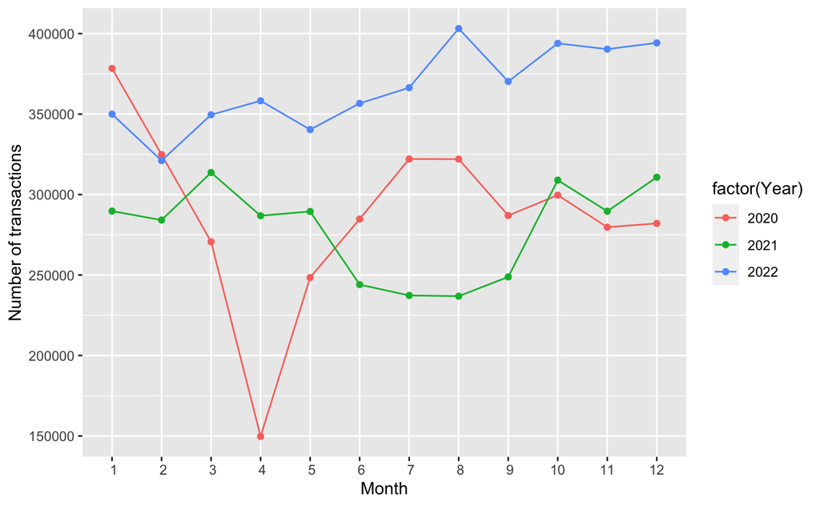

```r
trans.number <- df %>%
  group_by(Month = month(TransactionDate), Year = year(TransactionDate)) %>%
  summarise(trans.record = n()) %>%
  arrange(Year)
ggplot(data = trans.number, aes(x = Month, y = trans.record, group = Year,
                                colour = factor(Year))) +
  geom_line() +
  geom_point() +
  scale_x_discrete(limits = trans.number$Month) +
  ylab("Number of transactions")
```

Going deep into April 2020

```r
april2020 <-  df %>%
  filter(year(TransactionDate) == 2020) %>%
  filter(month(TransactionDate) == 4) %>%
  group_by(Day = day(TransactionDate)) %>%
  summarise(trans.recorded = n())

view(april2020)
```

There are no “missing” data apparently, just low values. Filtering by month number it’s possible to check how many stores made a sale during that particular month compared to the total number of stores that made at least one sale during 2020

```r
month2020.wide <- df %>%
  filter(year(TransactionDate) == 2020) %>%
  filter(month(TransactionDate) == 4)

length(unique(month2020.wide$StoreKey))
```

```
[1] 513
```

```r
length(unique(df[year(df$TransactionDate) == 2020,]$StoreKey))
```

```
[1] 600
```

# Days of the week

```r
# Re-ordering levels

df$DayOfWeek <- factor(df$DayOfWeek,
                       levels=c('Monday', 'Tuesday', 'Wednesday',
                                'Thursday', 'Friday', 'Saturday',
                                'Sunday'))

# Checking frequencies
table(df$DayOfWeek)
```

```
   Monday   Tuesday Wednesday  Thursday    Friday  Saturday    Sunday
  1491410   1446772   1462623   1498122   1610926   1841648   1832459
```

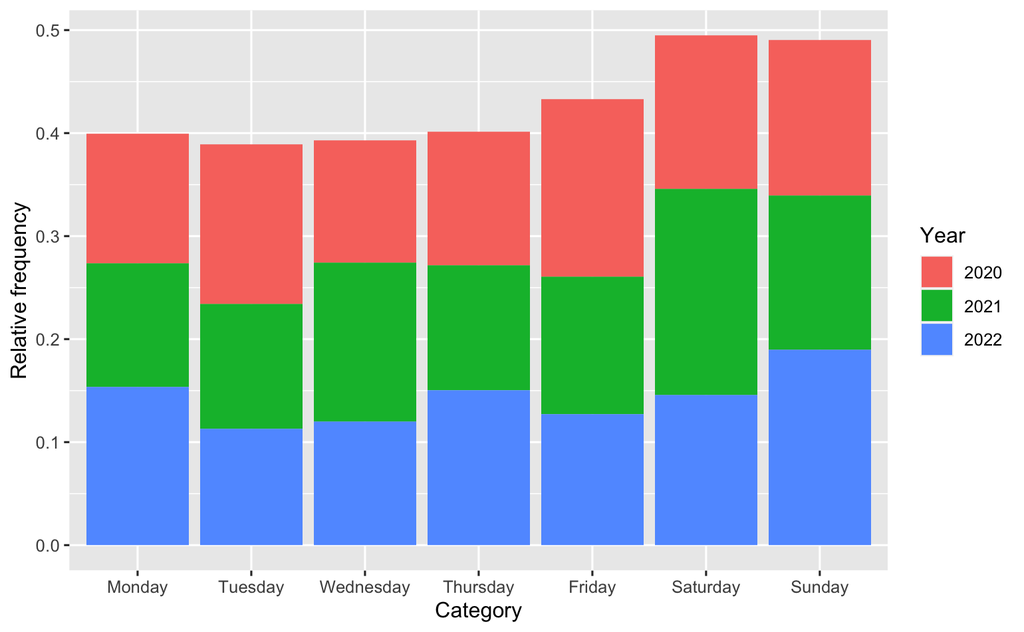

```r
dayoftheweek.plot <- df %>%
  group_by(year(TransactionDate), df$DayOfWeek) %>%
  summarise(Frequency = n())
dayoftheweek.plot$Year <- rep(c("2020", "2021", "2022"), 7)

dayoftheweek.plot <- dayoftheweek.plot %>%
  group_by(Year) %>%
  mutate(rel.frequency = Frequency/sum(Frequency))

dayoftheweek.plot$Day <- factor(dayoftheweek.plot$`df$DayOfWeek`,
                                levels=c('Monday', 'Tuesday', 'Wednesday',
                                         'Thursday', 'Friday', 'Saturday',
                                         'Sunday'))

ggplot(dayoftheweek.plot, aes(x = Day, y = rel.frequency, fill = Year)) +
  geom_bar(position = "stack", stat = "identity") +
  labs(x = "Category", y = "Relative frequency")
```

Transaction more or less disstributed throughout the week with a peak from Friday to Sunday

## Weekend Flag

```r
table(df$WeekendFlag)
```

```
  False    True
7509853 3674107
```

# Stores overview

```r
# Select the year
yr <- "2020"

store.summary <- df %>%
  select(StoreKey, StoreType, Region_Lvl1, Region_Lvl2, ActualSales, TransactionDate) %>%
  filter(year(TransactionDate) == yr) %>%
  group_by(StoreKey, StoreType, Region_Lvl1, Region_Lvl2) %>%
  summarise(revenues = sum(ActualSales)) %>%
  mutate(txt = paste("Store: ",StoreKey, "\n",
                     "Yearly sales: ", round(revenues/1000, digits = 0),"k€", "\n",
                     "Region lvl.1: ", Region_Lvl1, "\n",
                     "Region lvl.2: ", Region_Lvl2)) %>%
  arrange(desc(revenues)) %>%
  ungroup()
# Preparing variables
store.summary$StoreKey <- as.character(store.summary$StoreKey)
```

```r
# Generating Layout
packing <- circleProgressiveLayout(store.summary$revenues, sizetype = "area")
data <- cbind(store.summary, packing)
data.gg <- circleLayoutVertices(packing, npoints = 50)

# Plot
p <- ggplot() +
  geom_polygon_interactive(data = data.gg,
                           aes(x = x, y = y, group = id, fill = id,
                               tooltip = data$txt[id], data_id = id),
                           colour = "black", alpha = 0.6) +
  scale_fill_viridis() +
  geom_text(data = data,
            aes(x = x, y = y, label = StoreKey),
            size = 2, colour = "black") +
  theme_void() +
  theme(legend.position = "none") +
  coord_equal()

# Interactive
widg <- ggiraph(ggobj = p, width_svg = 7, height_svg = 7)
widg
```

[interactive chart not shown]

How many stores opened or closed from 2020?

```r
stores.2020 <- unique(df$StoreKey[df$TransactionDate < as.POSIXct("2021-01-01",format = "%Y-%m-%d", tz = "")])
stores.2022 <- unique(df$StoreKey[df$TransactionDate > as.POSIXct("2022-01-01",format = "%Y-%m-%d", tz = "")])

# Stores closed
stores.2020[!(stores.2020 %in% stores.2022)]
```

```
 [1] "46"  "357" "543" "107" "733" "591" "201" "1"   "162" "152" "389" "247" "340" "569"
[15] "567" "110" "530" "595" "444" "890" "897" "719" "711" "787" "710" "801"
```

```r
print(paste(length(stores.2020[!(stores.2020 %in% stores.2022)]), "stores closed from 2020",
            sep = " "))
```

```
[1] "26 stores closed from 2020"
```

```r
# Stores opened
stores.2022[!(stores.2022 %in% stores.2020)]
```

```
  [1] "2059" "2043" "2099" "2045" "2016" "2083" "2109" "2093" "2054" "2033" "2078"
 [12] "2024" "2032" "2088" "2046" "2056" "2100" "2040" "2039" "2050" "2030" "2036"
 [23] "2066" "2041" "2017" "2065" "2101" "2058" "2052" "2038" "2028" "2073" "2020"
 [34] "2018" "2079" "2029" "2037" "2014" "2069" "2022" "2021" "2080" "2092" "2089"
 [45] "2015" "2049" "2094" "2042" "2063" "2011" "2027" "2031" "2086" "2112" "2012"
 [56] "2019" "807"  "2068" "2105" "697"  "2076" "2035" "2103" "2053" "2087" "2051"
 [67] "2082" "2081" "2091" "2010" "2072" "2064" "2104" "2023" "2013" "2075" "2060"
 [78] "2025" "2026" "2057" "731"  "2115" "2061" "2077" "2047" "2067" "2070" "2048"
 [89] "2106" "2071" "2044" "2062" "2113" "2118" "2095" "2034" "2055" "2098" "2097"
[100] "2096" "2084" "2090" "2107" "2110" "0"    "2074" "2102" "2114" "2116" "2111"
[111] "789"  "2108" "729"  "2117" "782"  "744"  "715"  "808"  "785"  "726"  "748"
[122] "805"
```

```r
print(paste(length(stores.2022[!(stores.2022 %in% stores.2020)]), "stores opened from 2020"))
```

```
[1] "122 stores opened from 2020"
```

```r
remove(stores.2020, stores.2022)
```

# ProductCategory

```r
table(df$ProductCategory_Lvl2)
```

```
     AA      AB      AC      AD      AE
2652670 3664798 4016163   72824  777505
```

# Product Category

```r
# Select product category
prod.cat <- c("AA", "AB", "AC", "AD", "AE")

transactions.sag <- df %>%
  select(TransactionDate, ActualSales, ProductCategory_Lvl2) %>%
  filter(ProductCategory_Lvl2 %in% prod.cat) %>%
  group_by(ProductCategory_Lvl2) %>%
  arrange(TransactionDate) %>%
  mutate(cum_rev = cumsum(ActualSales))
```

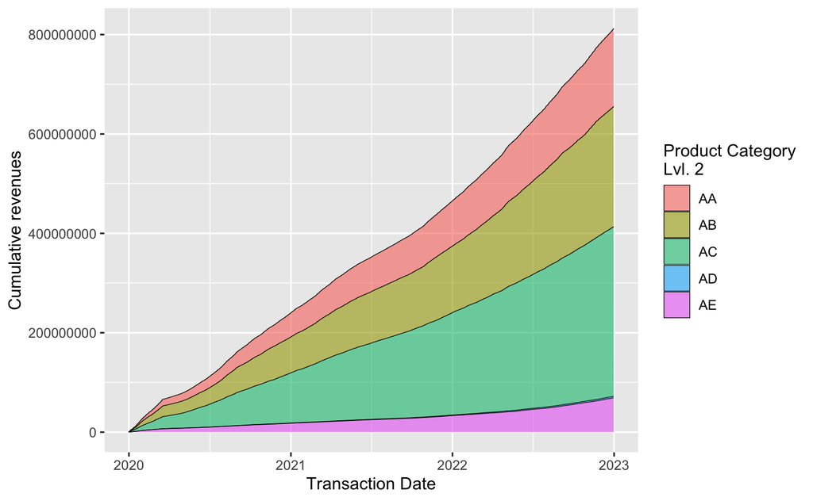

```r
ggplot(data = transactions.sag, aes(x = TransactionDate, y = cum_rev,
                                    fill = ProductCategory_Lvl2)) +
  labs(fill = "Product Category\nLvl. 2",
       x = "Transaction Date",y = "Cumulative revenues" ) +
  geom_area(color = "black", linewidth = 0.2, alpha = 0.6)
```

AD products are irrelevant when compared to other categories, AE shows a really slow growth, while AA, AB, AC are the best categories in terms of volumes and growth.

```r
cat.performances <- transactions.sag %>%
  group_by(ProductCategory_Lvl2, Year = year(TransactionDate)) %>%
  summarise(total.sales = sum(ActualSales)) %>%
  arrange(Year)
sum(cat.performances$total.sales[cat.performances$Year == 2022 & (cat.performances$ProductCategory_Lvl2 == "AA" | cat.performances$ProductCategory_Lvl2 == "AB" | cat.performances$ProductCategory_Lvl2 == "AC")]) / sum(cat.performances$total.sales[cat.performances$Year == 2022])
```

```
[1] 0.8920651
```

# Distribution channels

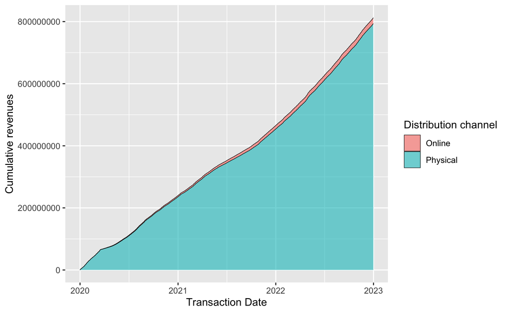

```r
# Select distribution channel
dist.channel <- c("Physical", "Online")

dist.channel.sag <- df %>%
  select(TransactionDate, ActualSales, DistributionChannel) %>%
  filter(DistributionChannel %in% dist.channel) %>%
  group_by(DistributionChannel) %>%
  arrange(TransactionDate) %>%
  mutate(cum_rev = cumsum(ActualSales))

ggplot(data = dist.channel.sag, aes(x = TransactionDate, y = cum_rev,
                                    fill = DistributionChannel)) +
  labs(fill = "Distribution channel",
       x = "Transaction Date",y = "Cumulative revenues" ) +
  geom_area(color = "black", linewidth = 0.2, alpha = 0.6)
```

Online distribution channel is a very narrow revenues source with low growth

```r
sum(dist.channel.sag$ActualSales[year(dist.channel.sag$TransactionDate) == 2022 & dist.channel.sag$DistributionChannel == "Online"]) / sum(dist.channel.sag$ActualSales[year(dist.channel.sag$TransactionDate) == 2022])
```

```
[1] 0.02145844
```

# Regional distribution

```r
# Select regions to exclude
regions.exclude.Lvl1 <- c("") # Lvl 1 regions to exclude
regions.exclude.Lvl2 <- c("") # Lvl 2 regions to exclude

reg.distribution.sag <- df %>%
  select(TransactionDate, ActualSales, Region_Lvl2, Region_Lvl1) %>%
  filter(!(Region_Lvl1 %in% regions.exclude.Lvl1) |
           !(Region_Lvl2 %in% regions.exclude.Lvl2)) %>%
  group_by(Region_Lvl2, Region_Lvl1) %>%
  arrange(TransactionDate) %>%
  mutate(cum_rev = cumsum(ActualSales))
```

```r
empty.regions <- df %>%
  filter(is.na(Region_Lvl2))
view(empty.regions)
```

StoreKey = 0 is linked to the online distribution channel